# Longitudinal Visualisation of DASS21 Subscale Scores Across a Simulated Cohort

Author

Julian Chung

## 1 Introduction

The Depression Anxiety Stress Scales (DASS21) is a self-report instrument designed to measure the emotional states of depression, anxiety, and stress. The short-form DASS21 contains 21 items divided evenly across the three subscales. Each item is scored from 0 to 3, and subscale totals are multiplied by 2 to align with the original DASS42 severity classification thresholds.

This project provides a brief example of how longitudinal DASS21 data might be visualised for a cohort in a clinical trial context. Specifically, we simulate the effects of an intervention on DASS21 scores over five timepoints: baseline, 3, 6, 9, and 12 months. This simulation includes both an intervention and a control group and mirrors REDCap-style data output.

## 2 Simulation Logic

The dataset used in this analysis was generated using a Python script to simulate individual DASS21 item responses across five timepoints for 20 participants in each group. For the intervention group, an item-level treatment effect was applied to reduce scores by 20% after baseline.

The Python script: - Simulates REDCap-style output with Q1–Q21 and total subscale scores - Applies realistic item distributions using weighted probabilities - Aggregates items into DASS subscale scores (Depression, Anxiety, Stress)

This simulated dataset was designed to replicate the layout and structure of typical REDCap CSV exports used in clinical trials. Because real participant-level data cannot be shared, this approach enables the visualisation framework to be demonstrated without exposing sensitive information.

A separate Python script was used to confirm that the simulated intervention and control groups produced discernible differences in mean DASS21 subscale scores across timepoints. The effect size modifier was adjusted iteratively until a realistic, interpretable difference was achieved.

This scaffolding could be reused in future studies with real REDCap data, enabling clinicians or trial monitors to track psychological changes across timepoints. The framework is readily extensible to total DASS scores or other patient-reported outcome (PRO) instruments such as the PHQ-9 or EQ-5D.

**Show Python Simulation Code**

```python
import pandas as pd
import numpy as np
import os

# Set random seed for reproducibility
np.random.seed(42)

# Assigning Parameters
n_per_group = 20
timepoints = ["baseline", "3_months", "6_months", "9_months", "12_months"]
groups = ["intervention", "control"]
questions = [f"Q{i}" for i in range(1, 22)]

# Mapping the DASS21 questions to their respective subscales
dass_anxiety = ["Q2", "Q4", "Q7", "Q9", "Q15", "Q19", "Q20"]
dass_depression = ["Q3", "Q5", "Q10", "Q13", "Q16", "Q17", "Q21"]
dass_stress = ["Q1", "Q6", "Q8", "Q11", "Q12", "Q14", "Q18"]

# Creating an effect modifier to apply to the treatment group
def apply_treatment_effect(scores, effect_size=0.2):
    return np.clip(np.round(scores * (1 - effect_size)), 0, 3).astype(int)

# Generate data
data = []

for group in groups:
    for subject_id in range(1, n_per_group + 1):
        full_id = f"{group[:1].upper()}{subject_id:02d}"
        for time in timepoints:
            row = {
                "id": full_id,
                "group": group,
                "timepoint": time
            }
            for q in questions:
                base_score = np.random.choice([0, 1, 2, 3], p=[0.1, 0.2, 0.4, 0.3])
                if group == "intervention" and time != "baseline":
                    row[q] = apply_treatment_effect(np.array([base_score]))[0]
                else:
                    row[q] = base_score

            # Calculate subscale scores
            row["DASS_Anxiety"] = sum([row[q] for q in dass_anxiety])
            row["DASS_Depression"] = sum([row[q] for q in dass_depression])
            row["DASS_Stress"] = sum([row[q] for q in dass_stress])
            data.append(row)

# Create DataFrame
df = pd.DataFrame(data)

# Save to CSV
output_dir = "data"
os.makedirs(output_dir, exist_ok=True)
csv_path = os.path.join(output_dir, "simulated_dass21_full.csv")
df.to_csv(csv_path, index=False)
```

A separate python script was used to confirm that the simulated intervention and control groups produced discernible differences in mean DASS21 subscale scores across timepoints, the effect size modifier was adjusted until the desired result was achieved.

The result is a CSV ready for analysis in R.

To visually confirm if the intervention group is meaningfully different to the control group in the simulated data, we quickly inspect the distribution of total DASS21 scores at baseline.

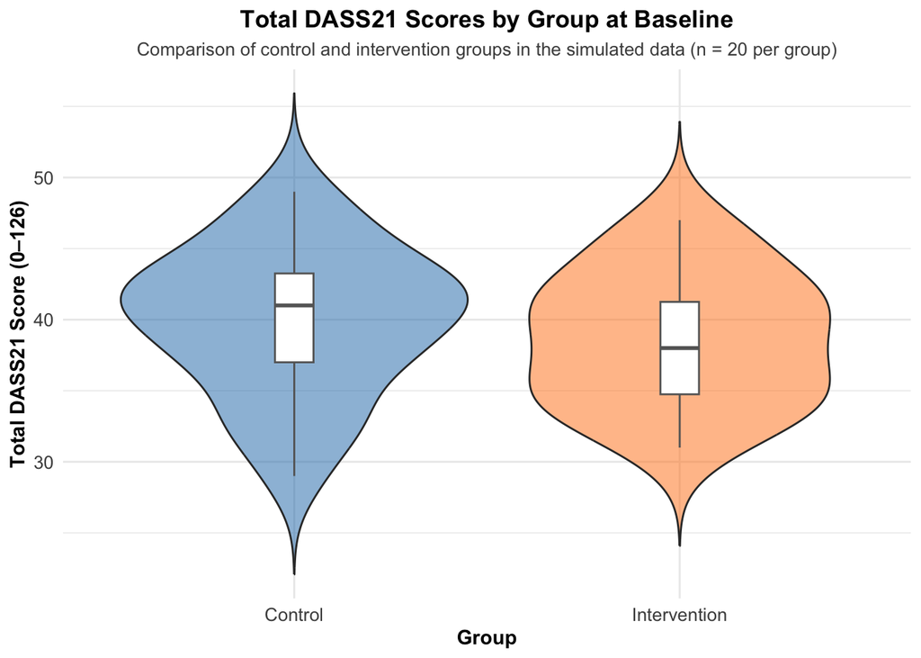

```r
suppressPackageStartupMessages(library(tidyverse))

# Load data
data <- read.csv(here::here("data", "simulated_dass21_full.csv"))

# Prepare baseline data
summary_plot_data <- data %>%
  filter(timepoint == "baseline") %>%
  mutate(
    total_score = DASS_Anxiety + DASS_Depression + DASS_Stress,
    group = factor(group, levels = c("control", "intervention"),
                  labels = c("Control", "Intervention"))
  )

# Plot
ggplot(summary_plot_data, aes(x = group, y = total_score, fill = group)) +
  geom_violin(trim = FALSE, alpha = 0.5, show.legend = FALSE) +
  geom_boxplot(
    width = 0.1,
    outlier.shape = NA,
    fill = "white",
    colour = "gray40",
    linewidth = 0.5
  ) +
  scale_fill_manual(values = c("Control" = "#1f77b4", "Intervention" = "#ff7f0e")) +
  labs(
    title = "Total DASS21 Scores by Group at Baseline",
    subtitle = "Comparison of control and intervention groups in the simulated data (n = 20 per group)",
    x = "Group",
    y = "Total DASS21 Score (0–126)"
  ) +
  theme_minimal() +
  theme(
    plot.title = element_text(hjust = 0.5, face = "bold"),
    plot.subtitle = element_text(hjust = 0.5, size = 10, color = "gray30"),
    axis.title.x = element_text(face = "bold"),
    axis.title.y = element_text(face = "bold"),
    axis.text = element_text(size = 10)
  )
```

## 3 Data Preparation

The subscale scores are first multiplied by 2 to align with DASS42 scoring conventions. The dataset is then reshaped into long format to enable visualisation of changes across timepoints and subscales.

```r
# Multiply subscale scores by 2 to match DASS42 scoring conventions
scored_data <- data %>%
  mutate(across(c(DASS_Anxiety, DASS_Depression, DASS_Stress), ~ .x * 2))

# Reshape to long format
dass_long <- scored_data %>%
  pivot_longer(cols = c(DASS_Anxiety, DASS_Depression, DASS_Stress),
              names_to = "subscale",
              values_to = "score") %>%
  mutate(timepoint = factor(timepoint, levels = c("baseline", "3_months", "6_months", "9_months", "12_months")))
```

## 4 Severity Classification

The DASS21 instrument includes three subscales: Depression, Anxiety, and Stress. After summing item responses and multiplying scores by 2, each subscale can be categorised into severity bands based on validated thresholds.

The severity bands are:

| Subscale | Normal | Mild | Moderate | Severe | Extremely Severe |
| --- | --- | --- | --- | --- | --- |
| Depression | 0–9 | 10–13 | 14–20 | 21–27 | 28+ |
| Anxiety | 0–7 | 8–9 | 10–14 | 15–19 | 20+ |
| Stress | 0–14 | 15–18 | 19–25 | 26–33 | 34+ |

```r
classify_severity <- function(score, subscale) {
  if (subscale == "DASS_Depression") {
    cut(score, breaks = c(-Inf, 9, 13, 20, 27, Inf),
        labels = c("Normal", "Mild", "Moderate", "Severe", "Extremely Severe"), right = TRUE)
  } else if (subscale == "DASS_Anxiety") {
    cut(score, breaks = c(-Inf, 7, 9, 14, 19, Inf),
        labels = c("Normal", "Mild", "Moderate", "Severe", "Extremely Severe"), right = TRUE)
  } else if (subscale == "DASS_Stress") {
    cut(score, breaks = c(-Inf, 14, 18, 25, 33, Inf),
        labels = c("Normal", "Mild", "Moderate", "Severe", "Extremely Severe"), right = TRUE)
  } else {
    return(NA)
  }
}

dass_long <- dass_long %>%
  mutate(severity_band = mapply(classify_severity, score, subscale))
```

## 5 Visualisation: Intervention Group

This visualisation demonstrates how individual participants’ subscale scores can be tracked across severity bands over time. By visualising Depression, Anxiety, and Stress trajectories separately, it becomes possible to assess how a treatment impacts specific psychological domains — and to detect patterns that might be masked in a total DASS21 score.

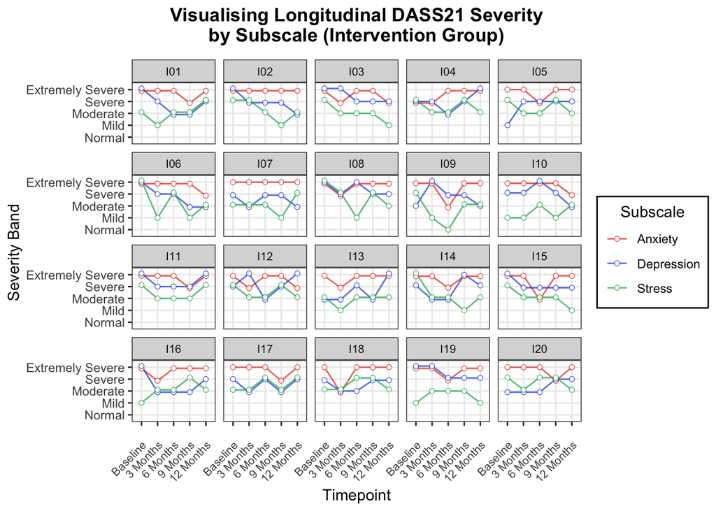

```r
intervention_data <- dass_long %>% filter(group == "intervention")

# Define timepoint labels
timepoint_labels <- c(
  "baseline" = "Baseline",
  "3_months" = "3 Months",
  "6_months" = "6 Months",
  "9_months" = "9 Months",
  "12_months" = "12 Months"
)

intervention_data$severity_band <- factor(intervention_data$severity_band,
                                          levels = c("Normal", "Mild", "Moderate", "Severe", "Extremely Severe"))

ggplot(intervention_data, aes(x = severity_band, y = timepoint, colour = subscale)) +
  geom_path(aes(group = interaction(id, subscale)),
            position = position_dodge(width = 0.4), alpha = 0.7) +
  geom_point(aes(group = interaction(id, subscale)),
            position = position_dodge(width = 0.4),
            size = 1.5, shape = 21, fill = "white", stroke = 0.3, alpha = 0.9) +
  scale_colour_manual("Subscale",
                      values = c("DASS_Anxiety" = "#E23418",
                                "DASS_Depression" = "#184CE2",
                                "DASS_Stress" = "#03AC50"),
                      labels = c("Anxiety", "Depression", "Stress")) +
  scale_y_discrete(labels = timepoint_labels) +
  coord_flip() +
  facet_wrap(~id) +
  theme_bw() +
  labs(
    title = "Visualising Longitudinal DASS21 Severity\nby Subscale (Intervention Group)",
    x = "Severity Band",
    y = "Timepoint"
  ) +
  theme(
    axis.text.y = element_text(angle = 0, hjust = 1),
    axis.text.x = element_text(angle = 45, size = 8, hjust = 1, margin = margin(t = 10)),
    plot.title = element_text(hjust = 0.5, face = "bold", margin = margin(b = 10)),
    strip.text = element_text(size = 8),
    legend.background = element_rect(fill = "white", colour = "black", linewidth = 0.5),
    legend.title = element_text(hjust = 0.5),
    legend.key = element_rect(fill = "white", colour = NA),
    legend.spacing.y = unit(5, "pt")
  )
```

This plot shows how individual participants responded across DASS21 subscales over 12 months with a simulated intervention.

## 6 Visualisation: Control Group

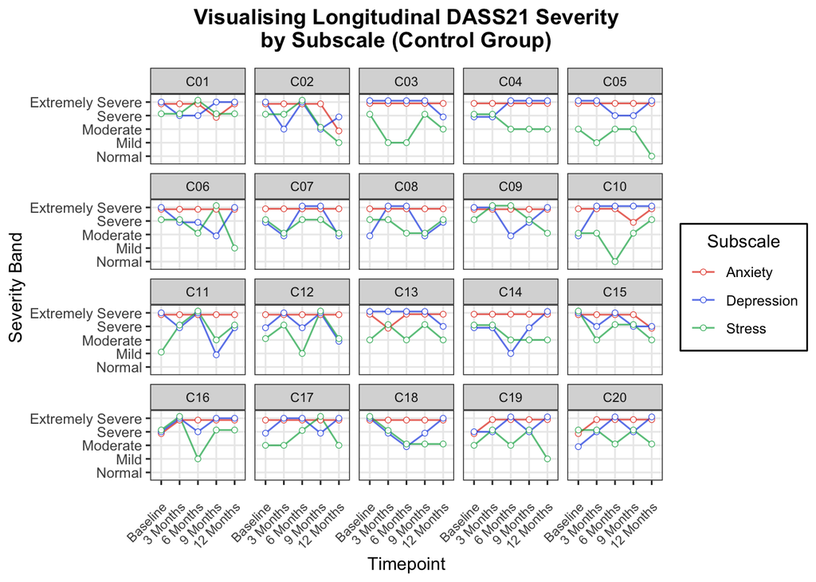

```r
control_data <- dass_long %>% filter(group == "control")

control_data$severity_band <- factor(control_data$severity_band,
                                    levels = c("Normal", "Mild", "Moderate", "Severe", "Extremely Severe"))

ggplot(control_data, aes(x = severity_band, y = timepoint, colour = subscale)) +
  geom_path(aes(group = interaction(id, subscale)),
            position = position_dodge(width = 0.4), alpha = 0.7) +
  geom_point(aes(group = interaction(id, subscale)),
            position = position_dodge(width = 0.4),
            size = 1.5, shape = 21, fill = "white", stroke = 0.3, alpha = 0.9) +
  scale_colour_manual("Subscale",
                      values = c("DASS_Anxiety" = "#E23418",
                                "DASS_Depression" = "#184CE2",
                                "DASS_Stress" = "#03AC50"),
                      labels = c("Anxiety", "Depression", "Stress")) +
  scale_y_discrete(labels = timepoint_labels) +
  coord_flip() +
  facet_wrap(~id) +
  theme_bw() +
  labs(
    title = "Visualising Longitudinal DASS21 Severity\nby Subscale (Control Group)",
    x = "Severity Band",
    y = "Timepoint"
  ) +
  theme(
    axis.text.y = element_text(angle = 0, hjust = 1),
    axis.text.x = element_text(angle = 45, size = 8, hjust = 1, margin = margin(t = 10)),
    plot.title = element_text(hjust = 0.5, face = "bold", margin = margin(b = 10)),
    strip.text = element_text(size = 8),
    legend.background = element_rect(fill = "white", colour = "black", linewidth = 0.5),
    legend.title = element_text(hjust = 0.5),
    legend.key = element_rect(fill = "white", colour = NA),
    legend.spacing.y = unit(5, "pt")
  )
```

This plotting approach can be easily adapted to visualise total DASS scores or applied to other repeated-measures instruments such as the PHQ-9 or EQ-5D.

## 7 Summary

This simulated visualisation demonstrates how individual-level DASS21 data could be presented longitudinally across multiple timepoints. Faceted plots by participant ID provide granular insight into symptom trajectories across depression, anxiety, and stress domains.

Such a visualisation could be used in early-phase trials, psychological studies, or pilot data analysis to: - Detect trends in subscale response that may be masked in aggregated DASS21 score - Identify participants with worsening symptoms - Compare intervention vs. control effectiveness visually - Quickly highlight concerning individual patterns (e.g., a participant worsening in depression despite treatment)

By allowing clinicians or trial monitors to glance across a cohort and pinpoint which domain is driving deterioration or improvement, this approach provides a clear advantage over reporting only total scores. While this demonstration focuses on DASS21 subscales, the same framework could be adapted to visualise total DASS scores or other common patient-reported outcome (PRO) instruments such as the PHQ-9 or EQ-5D.

Future enhancements might include summary panels, group-level means, or animated progression across timepoints.

## 8 References

[Depression Anxiety Stress Scale-21 (DASS21)](https://arc.psych.wisc.edu/self-report/depression-anxiety-stress-scale-21-dass21/)

[DASS-21 Scoring template and interpretation](https://comorbidityguidelines.org.au/appendix-k-depression-anxiety-stress-scale-dass-21/dass21-scoring-template-and-interpretation)

[Manual for the Depression Anxiety Stress Scales. (2nd. Ed.) Sydney: Psychology Foundation.](https://raw.githubusercontent.com/jjcurtin/arc_measures/main/DASS21/DASS21.R)

*This project was derived from work on a real clinical trial dataset, modified here with synthetic data for demonstration. It showcases the workflow in Python, R, Quarto, and ggplot2 for longitudinal visualisation.*